# Practical Machine Learning: Prediction Assignment Writeup

Soumya Patra

2 March 2017

## Background

Using devices such as Jawbone Up, Nike FuelBand, and Fitbit it is now possible to collect a large amount of data about personal activity relatively inexpensively. These type of devices are part of the quantified self movement. A group of enthusiasts who take measurements about themselves regularly to improve their health, to find patterns in their behavior, or because they are tech geeks. One thing that people regularly do is quantify how much of a particular activity they do, but they rarely quantify how well they do it. In this project, your goal will be to use data from accelerometers on the belt, forearm, arm, and dumbell of 6 participants. They were asked to perform barbell lifts correctly and incorrectly in 5 different ways. More information is available from the website here: http://groupware.les.inf.puc-rio.br/har.

## Summary

The goal of the project is to predict the manner in which the exercises were performed. This is the “classe” variable in the training set. We will other variables in the dataset to predict the “classe” variable. In the following sections, we describe how we built your model, how we used cross validation, what we think the expected out of sample error is. We will also use your prediction model to predict 20 different test cases.

## Preprocessing Data

We start with loading the training and test datasets. We can see below that traiining dataset has 19622 records with 160 columns and test dataset has 20 records with the same amount of columns.

```r
trainingData <- read.csv(url("https://d396qusza40orc.cloudfront.net/predmachlearn/pml-training.csv"), na.strings=c("", "NA", "NULL"))
dim(trainingData)
```

```
## [1] 19622   160
```

```r
testData <- read.csv(url("https://d396qusza40orc.cloudfront.net/predmachlearn/pml-testing.csv"), na.strings=c("", "NA", "NULL"))
dim(testData)
```

```
## [1]  20 160
```

```r
nas <- sapply(trainingData, function(column) any(is.na(column)))
trainingData <- trainingData[, nas == FALSE]
rem <- c("X", "user_name", "raw_timestamp_part_1", "raw_timestamp_part_2", "cvtd_timestamp")
trainingData <- trainingData[,!(names(trainingData) %in% rem)]
dim(trainingData)
```

```
## [1] 19622    55
```

After preprocessing the data, we split the data into training and test sets considering *classe* column as the outcome. For this project, we choose to have 70% data for the training set and hence 30% data is considered as test set.

```r
library(caret)
set.seed(93425)
train <- createDataPartition(trainingData$classe, p=0.7, list=FALSE)
trainingSet <- trainingData[train,]
testingSet <- trainingData[-train,]
dim(trainingSet)
```

```
## [1] 13737    55
```

```r
dim(testingSet)
```

```
## [1] 5885   55
```

## Predictive Modelling

We start with creating a decision tree model. When we use the model with the testing set, we get an accuracy of only 74%. Therefore we don’t consider this as our final model. We can see the decision tree in the plot shown below.

```r
library(rpart)
```

```r
library(rpart.plot)
set.seed(93425)
treeModel <- rpart(classe ~ ., data=trainingSet, method="class")
predictTree <- predict(treeModel, newdata=testingSet, type="class")
confusionMatrix(predictTree, testingSet$classe)
```

```
## Confusion Matrix and Statistics
##
##           Reference
## Prediction    A    B    C    D    E
##          A 1469  188   39   73   44
##          B   56  687   57   76  115
##          C   19   81  837  134   90
##          D   87  145   68  637  122
##          E   43   38   25   44  711
##
## Overall Statistics
##
##                Accuracy : 0.7376
##                  95% CI : (0.7262, 0.7488)
##     No Information Rate : 0.2845
##     P-Value [Acc > NIR] : < 2.2e-16
##
##                   Kappa : 0.6675
##  Mcnemar's Test P-Value : < 2.2e-16
##
## Statistics by Class:
##
##                      Class: A Class: B Class: C Class: D Class: E
## Sensitivity            0.8775   0.6032   0.8158   0.6608   0.6571
## Specificity            0.9183   0.9359   0.9333   0.9142   0.9688
## Pos Pred Value         0.8103   0.6932   0.7209   0.6015   0.8258
## Neg Pred Value         0.9497   0.9076   0.9600   0.9322   0.9262
## Prevalence             0.2845   0.1935   0.1743   0.1638   0.1839
## Detection Rate         0.2496   0.1167   0.1422   0.1082   0.1208
## Detection Prevalence   0.3081   0.1684   0.1973   0.1799   0.1463
## Balanced Accuracy      0.8979   0.7696   0.8746   0.7875   0.8129
```

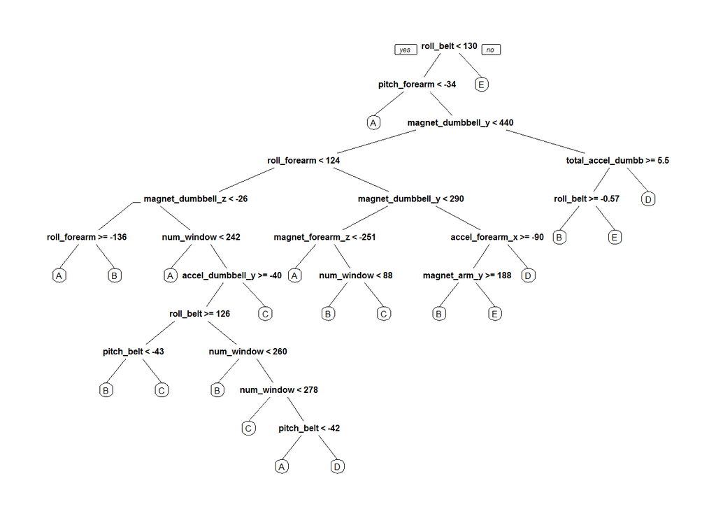

```r
prp(treeModel)
```

```r
library(randomForest)
set.seed(93425)
fitControl <- trainControl(method = "cv", number=5)
randomForest <- train(classe ~ ., data=trainingSet, method="rf", trControl=fitControl)
randomForest$finalModel
```

```
##
## Call:
##  randomForest(x = x, y = y, mtry = param$mtry)
##                Type of random forest: classification
##                      Number of trees: 500
## No. of variables tried at each split: 28
##
##         OOB estimate of  error rate: 0.23%
## Confusion matrix:
##      A    B    C    D    E  class.error
## A 3905    1    0    0    0 0.0002560164
## B    7 2649    2    0    0 0.0033860045
## C    0    4 2390    2    0 0.0025041736
## D    0    0   11 2240    1 0.0053285968
## E    0    0    0    4 2521 0.0015841584
```

```r
prediction <- predict(randomForest, newdata=testingSet)
confusionMatrix(prediction, testingSet$classe)
```

```
## Confusion Matrix and Statistics
##
##           Reference
## Prediction    A    B    C    D    E
##          A 1673    4    0    0    0
##          B    0 1132    2    0    0
##          C    0    3 1024    7    0
##          D    0    0    0  957    2
##          E    1    0    0    0 1080
##
## Overall Statistics
##
##                Accuracy : 0.9968
##                  95% CI : (0.995, 0.9981)
##     No Information Rate : 0.2845
##     P-Value [Acc > NIR] : < 2.2e-16
##
##                   Kappa : 0.9959
##  Mcnemar's Test P-Value : NA
##
## Statistics by Class:
##
##                      Class: A Class: B Class: C Class: D Class: E
## Sensitivity            0.9994   0.9939   0.9981   0.9927   0.9982
## Specificity            0.9991   0.9996   0.9979   0.9996   0.9998
## Pos Pred Value         0.9976   0.9982   0.9903   0.9979   0.9991
## Neg Pred Value         0.9998   0.9985   0.9996   0.9986   0.9996
## Prevalence             0.2845   0.1935   0.1743   0.1638   0.1839
## Detection Rate         0.2843   0.1924   0.1740   0.1626   0.1835
## Detection Prevalence   0.2850   0.1927   0.1757   0.1630   0.1837
## Balanced Accuracy      0.9992   0.9967   0.9980   0.9962   0.9990
```

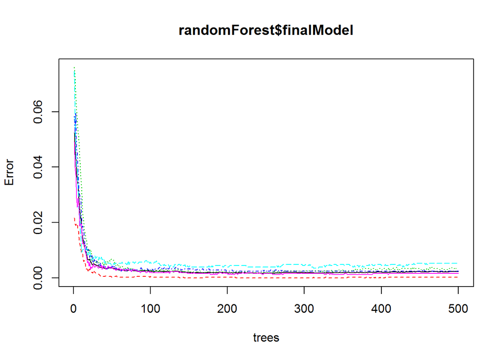

```r
plot(randomForest$finalModel)
```

## Conclusion

Being an ensemble learning method, Random forest model provides a highly accurate model to us. Therefore, we use this model to predict the 20 observations given in the validation test data. We find that the model is correctly able to predict all the 20 observations for us.

```r
predictValidation <- predict(randomForest, newdata=testData)
predictValidation
```

```
##  [1] B A B A A E D B A A B C B A E E A B B B
## Levels: A B C D E
```